# Study 1: Point duration in English-learners, ASL-learners and homesigners

Descriptive statistics and figures

This report produces Table 1, Figures 1 to 3, Table S2 and Figures S1 to S3, and the descriptive statistics given in their captions.

In the figures, dashed and dotted lines mark arithmetic means. The models in `study1_duration_models.Rmd` report geometric means, which are lower because durations are right-skewed.

```r
source("R/prepare_data.R")
suppressPackageStartupMessages({
  library(tidyr)
  library(ggplot2)
  library(knitr)
})
dir.create("figures", showWarnings = FALSE)
options(knitr.kable.NA = "")

points <- combined_df %>% filter(modality == "Points")
stopifnot(all(is.na(combined_df$duration_sec[combined_df$modality == "Pronouns"])))

# Child labels used in the manuscript. Homesigners are numbered by age at first
# observation, as in Table 1.
child_label <- c(ABY = "ASL1", JIL = "ASL2", NED = "ASL3",
                 UCHS05 = "HS1", UCHS02 = "HS2", UCHS003 = "HS3")
```

# 1 Coded points

```r
points %>%
  group_by(language) %>%
  summarise(children = n_distinct(subject), coded_points = n(),
            with_duration = sum(!is.na(duration_sec)), .groups = "drop") %>%
  kable(caption = "Points coded in each group, and points with a measured duration")
```

Points coded in each group, and points with a measured duration

| language | children | coded_points | with_duration |
| --- | --- | --- | --- |
| ASL | 3 | 1126 | 1126 |
| English | 10 | 2354 | 511 |
| Homesign | 3 | 791 | 791 |

# 2 Table 1

Number of children observed at each age and, in parentheses, the number of points they produced. Homesigners’ sessions are placed in the nearest four-month column.

```r
ages <- c("1;06", "1;10", "2;02", "2;06", "2;10", "3;02", "3;06", "3;10")
cell <- function(k, n) sprintf("%d (%d)", k, n)

learners <- points %>%
  filter(language != "Homesign") %>%
  group_by(language, age) %>%
  summarise(cell = cell(n_distinct(subject), n()), .groups = "drop") %>%
  pivot_wider(names_from = age, values_from = cell)
per_child <- points %>% filter(language != "Homesign") %>%
  group_by(language) %>% summarise(per_child = round(n() / n_distinct(subject)), .groups = "drop")

homesign_column <- c("1;06" = "1;06", "1;10" = "1;10", "2;02" = "2;02", "2;10" = "2;10",
                     "3;00" = "3;02", "3;03" = "3;02", "3;05" = "3;06",
                     "3;10" = "3;10", "3;11" = "3;10")
homesigners <- homesign_raw %>%
  filter(!is.na(Subject), Subject != "") %>%
  mutate(column = homesign_column[Age]) %>%
  count(Subject, column) %>%
  group_by(language = child_label[Subject]) %>%
  mutate(per_child = sum(n)) %>%
  ungroup() %>%
  transmute(language, column, cell = cell(1L, n), per_child) %>%
  pivot_wider(names_from = column, values_from = cell)
stopifnot(!anyNA(homesigners$language))

bind_rows(left_join(learners, per_child, by = "language"), homesigners) %>%
  mutate(language = recode(language, English = "English-learners", ASL = "ASL-learners")) %>%
  select(group = language, any_of(ages), per_child) %>%
  arrange(match(group, c("English-learners", "ASL-learners", "HS1", "HS2", "HS3"))) %>%
  kable(caption = "Table 1")
```

Table 1

| group | 1;06 | 1;10 | 2;02 | 2;06 | 2;10 | 3;02 | 3;06 | 3;10 | per_child |
| --- | --- | --- | --- | --- | --- | --- | --- | --- | --- |
| English-learners | 10 (356) | 10 (593) | 10 (675) | 10 (575) | 10 (155) |  |  |  | 235 |
| ASL-learners | 3 (45) | 3 (128) | 3 (281) | 3 (282) | 3 (390) |  |  |  | 375 |
| HS1 | 1 (24) | 1 (7) | 1 (84) |  |  |  |  |  | 115 |
| HS2 |  |  |  |  | 1 (8) | 1 (13) |  | 1 (78) | 99 |
| HS3 |  |  |  |  | 1 (27) | 1 (69) | 1 (198) | 1 (283) | 577 |

# 3 Figure 1

Mean number of points per observation session in each of the nine semantic roles. Each role’s count is divided by the number of sessions in the group, so sessions in which a role did not occur count as zero. Homesigners’ sessions are counted as recording files, because two pairs of their sessions fall in the same four-month interval.

```r
roles <- c("actor", "patient", "recipient", "place", "instrument",
           "source", "entity", "possessor", "location")
coded <- points %>%
  filter(!is.na(semantic_cat)) %>%
  mutate(group = recode(language, English = "English-learners",
                        ASL = "ASL-learners", Homesign = "Homesigners"))
sessions <- c(
  "English-learners" = nrow(distinct(filter(coded, language == "English"), subject, age)),
  "ASL-learners"     = nrow(distinct(filter(coded, language == "ASL"), subject, age)),
  "Homesigners"      = nrow(distinct(filter(homesign_raw, !is.na(Subject), Subject != ""), File)))
sessions
```

```
## English-learners     ASL-learners      Homesigners
##               50               15               10
```

```r
fig1_data <- coded %>%
  filter(semantic_cat %in% roles) %>%
  count(group, semantic_cat) %>%
  mutate(per_session = n / sessions[group],
         group = factor(group, levels = names(sessions)),
         semantic_cat = factor(semantic_cat, levels = c(roles, "unclear")))
fig1_data %>% group_by(group) %>%
  summarise(points = sum(n), points_per_session = sum(per_session), .groups = "drop") %>%
  kable(digits = 1)
```

| group | points | points_per_session |
| --- | --- | --- |
| English-learners | 2198 | 44.0 |
| ASL-learners | 1044 | 69.6 |
| Homesigners | 653 | 65.3 |

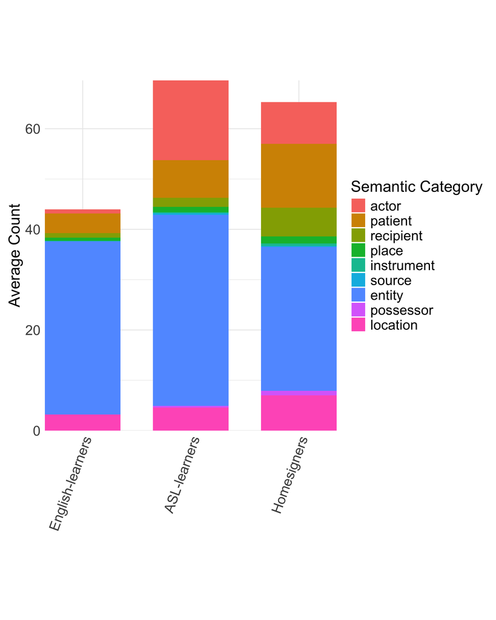

```r
fig1 <- ggplot(fig1_data, aes(x = group, y = per_session, fill = semantic_cat)) +
  geom_bar(stat = "identity", position = "stack", width = 0.7) +
  scale_fill_discrete(name = "Semantic Category") +
  labs(x = "", y = "Average Count") +
  theme_minimal() +
  theme(axis.text.x = element_text(size = 16, angle = 70, hjust = 1, vjust = 1),
        axis.text.y = element_text(size = 16),
        axis.title.y = element_text(size = 18),
        legend.text = element_text(size = 16),
        legend.title = element_text(size = 18),
        aspect.ratio = 1.2,
        panel.background = element_rect(fill = "white", color = NA),
        plot.background = element_rect(fill = "white", color = NA),
        plot.margin = margin(t = 10, r = 10, b = 5, l = 10)) +
  coord_cartesian(expand = FALSE)
fig1
```

```r
ggsave("figures/Figure1.png", fig1, width = 5.02 * 1.6, height = 6.26 * 1.6, dpi = 300, bg = "white")
```

# 4 Figures 2 and 3

Density of point durations in each group, for all points (Figure 2) and for points produced alone (Figure 3). Kernel density estimates use ggplot2’s default Gaussian kernel and bandwidth (Silverman’s rule of thumb). The x-axis ends at 8 s.

```r
duration_density <- function(d) {
  means <- d %>% group_by(language) %>%
    summarise(mean_duration = mean(duration_sec, na.rm = TRUE), .groups = "drop")
  labels <- c("English-learners", "ASL-learners", "Homesigners")
  ggplot(d, aes(x = duration_sec, fill = language, color = language)) +
    geom_density(alpha = 0.3) +
    geom_vline(data = means, aes(xintercept = mean_duration, color = language),
               linetype = "dashed", linewidth = 1) +
    labs(x = "Duration (seconds)", y = "Density") +
    scale_color_manual(values = scales::hue_pal()(3),
                       breaks = c("English", "ASL", "Homesign"), labels = labels) +
    scale_fill_manual(values = scales::hue_pal()(3),
                      breaks = c("English", "ASL", "Homesign"), labels = labels) +
    xlim(0, 8) + ylim(0, 0.8) +
    theme_bw() +
    theme(text = element_text(size = 17), axis.text = element_text(size = 17),
          axis.title = element_text(size = 17), legend.text = element_text(size = 17),
          legend.title = element_blank(),
          legend.key.height = unit(1.2, "lines"), legend.key.width = unit(1.2, "lines")) +
    guides(color = guide_legend(keyheight = 1.5), fill = guide_legend(keyheight = 1.5))
}
caption_stats <- function(d) d %>% filter(!is.na(duration_sec)) %>%
  group_by(language) %>%
  summarise(n = n(), mean_s = mean(duration_sec), sd_s = sd(duration_sec),
            longer_than_8s = sum(duration_sec > 8), .groups = "drop")

timed <- points %>% filter(!is.na(duration_sec))
alone <- timed %>% filter(utt_type %in% "point_alone")

kable(caption_stats(timed), digits = 2, caption = "Figure 2: all points")
```

Figure 2: all points

| language | n | mean_s | sd_s | longer_than_8s |
| --- | --- | --- | --- | --- |
| ASL | 1126 | 1.17 | 1.20 | 4 |
| English | 511 | 2.14 | 1.66 | 6 |
| Homesign | 791 | 1.37 | 1.26 | 5 |

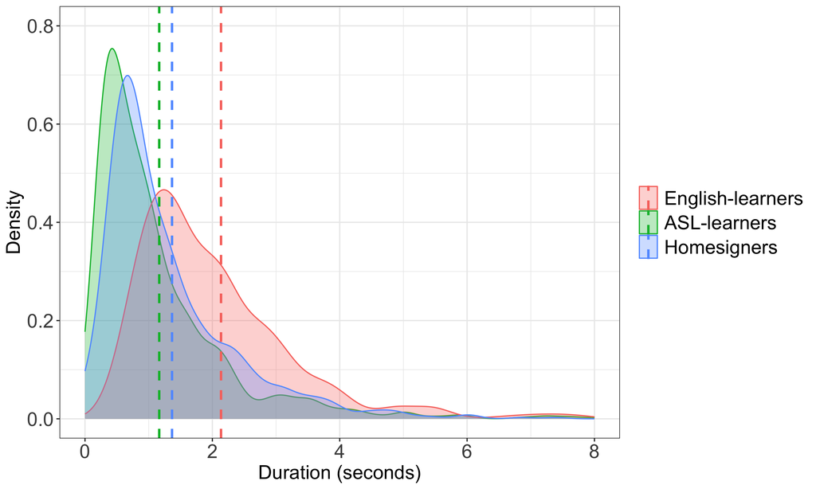

```r
fig2 <- duration_density(timed)
fig2
```

```r
ggsave("figures/Figure2.png", fig2, width = 10, height = 6, dpi = 300)

kable(caption_stats(alone), digits = 2, caption = "Figure 3: points produced alone")
```

Figure 3: points produced alone

| language | n | mean_s | sd_s | longer_than_8s |
| --- | --- | --- | --- | --- |
| ASL | 456 | 1.56 | 1.48 | 3 |
| English | 186 | 2.39 | 1.83 | 2 |
| Homesign | 402 | 1.53 | 1.36 | 3 |

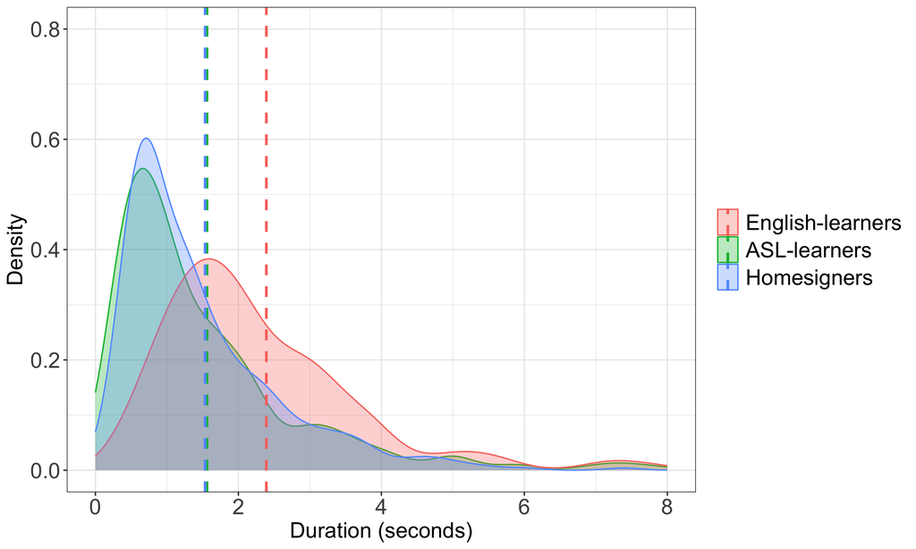

```r
fig3 <- duration_density(alone)
fig3
```

```r
ggsave("figures/Figure3.png", fig3, width = 10, height = 6, dpi = 300)
```

# 5 Table S2

Points with a measured duration, by child. Alone: percentage of the points with a coded context. Unclear, other and no role: points whose semantic role was coded as unclear or other, or was not coded; these points are excluded only from the models that control for semantic role.

```r
per_child <- function(d) d %>% summarise(
  points = n(), context_coded = sum(!is.na(utt_type)),
  alone = sprintf("%d (%.1f)", sum(utt_type %in% "point_alone"),
                  100 * sum(utt_type %in% "point_alone") / sum(!is.na(utt_type))),
  unclear = sum(semantic_cat %in% "unclear"), other = sum(semantic_cat %in% "other"),
  no_role = sum(is.na(semantic_cat)),
  duration_s = sprintf("%.2f (%.2f)", mean(duration_sec), sd(duration_sec)),
  .groups = "drop")

bind_rows(
  timed %>% mutate(child = coalesce(child_label[subject], subject)) %>%
    group_by(language, child) %>% per_child(),
  timed %>% mutate(child = "Total") %>% group_by(language, child) %>% per_child()) %>%
  arrange(match(language, c("English", "ASL", "Homesign")), child == "Total") %>%
  kable(caption = "Table S2")
```

Table S2

| language | child | points | context_coded | alone | unclear | other | no_role | duration_s |
| --- | --- | --- | --- | --- | --- | --- | --- | --- |
| English | 22 | 125 | 125 | 46 (36.8) | 0 | 0 | 0 | 2.32 (1.75) |
| English | 24 | 45 | 45 | 14 (31.1) | 0 | 9 | 0 | 1.94 (1.28) |
| English | 25 | 58 | 58 | 16 (27.6) | 2 | 0 | 5 | 2.26 (2.04) |
| English | 27 | 35 | 35 | 17 (48.6) | 0 | 2 | 0 | 2.09 (1.02) |
| English | 28 | 57 | 57 | 33 (57.9) | 0 | 0 | 0 | 1.89 (1.41) |
| English | 29 | 59 | 59 | 25 (42.4) | 3 | 0 | 0 | 2.53 (2.39) |
| English | 33 | 18 | 18 | 8 (44.4) | 0 | 2 | 0 | 1.07 (0.54) |
| English | 37 | 12 | 12 | 1 (8.3) | 0 | 1 | 0 | 2.07 (1.52) |
| English | 38 | 61 | 61 | 19 (31.1) | 0 | 6 | 0 | 2.16 (1.56) |
| English | 39 | 41 | 41 | 7 (17.1) | 0 | 6 | 0 | 1.89 (0.84) |
| English | Total | 511 | 511 | 186 (36.4) | 5 | 26 | 5 | 2.14 (1.66) |
| ASL | ASL1 | 508 | 508 | 184 (36.2) | 41 | 2 | 0 | 0.94 (0.96) |
| ASL | ASL2 | 334 | 334 | 132 (39.5) | 27 | 0 | 0 | 1.13 (1.09) |
| ASL | ASL3 | 284 | 284 | 140 (49.3) | 12 | 0 | 0 | 1.61 (1.54) |
| ASL | Total | 1126 | 1126 | 456 (40.5) | 80 | 2 | 0 | 1.17 (1.20) |
| Homesign | HS1 | 115 | 109 | 73 (67.0) | 10 | 0 | 3 | 1.54 (1.30) |
| Homesign | HS2 | 99 | 86 | 63 (73.3) | 3 | 0 | 18 | 1.83 (1.62) |
| Homesign | HS3 | 577 | 542 | 266 (49.1) | 93 | 0 | 11 | 1.25 (1.15) |
| Homesign | Total | 791 | 737 | 402 (54.5) | 106 | 0 | 32 | 1.37 (1.26) |

```r
timed %>% filter(language == "Homesign", is.na(utt_type)) %>% nrow()
```

```
## [1] 54
```

The last line is the number of homesigner points with no coded context. These points are in the all-points models but in none of the models of context.

# 6 Figures S1 to S3

Density of point durations at each age, for each group (Figure S1), each ASL-learner (Figure S2) and each homesigner (Figure S3). Blue dotted lines show the mean of each panel; black dotted lines show the group’s mean across ages (Figure S1) or the mean of the three ASL-learners at that age (Figure S2). The x-axis ends at 6 s; longer points are omitted from the densities but included in the means and SDs.

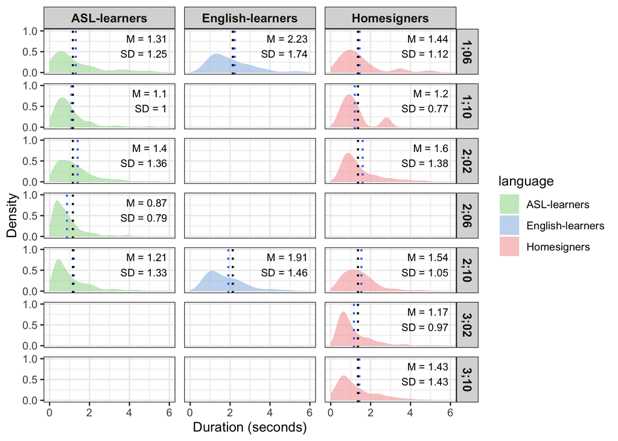

```r
s1_data <- timed %>%
  mutate(language = factor(recode(language, English = "English-learners",
                                  ASL = "ASL-learners", Homesign = "Homesigners"),
                           levels = c("ASL-learners", "English-learners", "Homesigners")))
panel_stats <- s1_data %>% group_by(age, language) %>%
  summarise(panel_mean = mean(duration_sec), sd = sd(duration_sec), .groups = "drop") %>%
  mutate(label = paste0("M = ", round(panel_mean, 2), "\nSD = ", round(sd, 2)))
group_means <- panel_stats %>% select(age, language) %>%
  left_join(s1_data %>% group_by(language) %>%
              summarise(group_mean = mean(duration_sec), .groups = "drop"), by = "language")

fig_s1 <- ggplot(s1_data, aes(x = duration_sec, fill = language)) +
  geom_density(alpha = 0.6, color = NA) +
  geom_vline(data = panel_stats, aes(xintercept = panel_mean),
             linetype = "dotted", linewidth = 0.8, color = "royalblue1", inherit.aes = FALSE) +
  geom_vline(data = group_means, aes(xintercept = group_mean),
             linetype = "dotted", linewidth = 0.8, color = "black", inherit.aes = FALSE) +
  geom_text(data = panel_stats, aes(x = 5.9, y = 0.9, label = label),
            hjust = 1, vjust = 1, size = 3, color = "black", inherit.aes = FALSE) +
  scale_fill_manual(values = c("ASL-learners" = "#A6DBA0", "Homesigners" = "#F4A6A6",
                               "English-learners" = "#9EC1E4"),
                    name = "language", drop = FALSE) +
  facet_grid(age ~ language, drop = FALSE) +
  labs(x = "Duration (seconds)", y = "Density") +
  theme_bw() +
  theme(strip.text = element_text(size = 10, face = "bold"),
        panel.spacing = unit(0.5, "lines"), legend.position = "right") +
  xlim(0, 6) +
  scale_y_continuous(breaks = c(0, 0.5, 1), limits = c(0, 1))
fig_s1
```

```r
ggsave("figures/FigureS1.png", fig_s1, width = 7, height = 5, dpi = 450)

timed %>% group_by(language) %>% summarise(longer_than_6s = sum(duration_sec > 6)) %>% kable()
```

| language | longer_than_6s |
| --- | --- |
| ASL | 12 |
| English | 13 |
| Homesign | 9 |

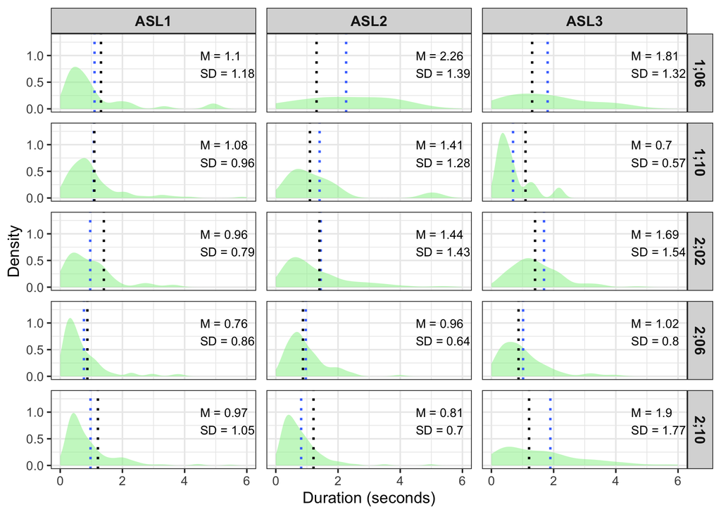

```r
# Per-child densities at each age. The y-axis extends to the highest density
# in any panel (computed on 0 to 6 s), with a minimum of 1.
child_density <- function(d, fill, age_means = FALSE) {
  d <- d %>% mutate(child = child_label[subject])
  peak <- d %>% group_by(age, child) %>%
    summarise(peak = if (n() > 1) max(density(duration_sec, from = 0, to = 6)$y) else 0,
              .groups = "drop")
  y_max <- max(1, max(peak$peak) * 1.1)
  panel_stats <- d %>% group_by(age, child) %>%
    summarise(panel_mean = mean(duration_sec), sd = sd(duration_sec), .groups = "drop") %>%
    mutate(label = paste0("M = ", round(panel_mean, 2), "\nSD = ", round(sd, 2)))
  p <- ggplot(d, aes(x = duration_sec)) +
    geom_density(fill = fill, alpha = 0.5, color = NA) +
    facet_grid(age ~ child, drop = TRUE) +
    labs(x = "Duration (seconds)", y = "Density") +
    theme_bw() +
    theme(strip.text = element_text(size = 10, face = "bold"),
          panel.spacing = unit(0.5, "lines")) +
    xlim(0, 6) +
    scale_y_continuous(breaks = c(0, 0.5, 1), limits = c(0, y_max)) +
    geom_text(data = panel_stats, aes(x = 4.5, y = y_max * 0.8, label = label),
              hjust = 0, vjust = 1, size = 3, color = "black") +
    geom_vline(data = panel_stats, aes(xintercept = panel_mean),
               linetype = "dotted", linewidth = 0.8, color = "royalblue1")
  if (age_means) {
    age_stats <- panel_stats %>% select(age, child) %>%
      left_join(d %>% group_by(age) %>% summarise(age_mean = mean(duration_sec)), by = "age")
    p <- p + geom_vline(data = age_stats, aes(xintercept = age_mean),
                        linetype = "dotted", linewidth = 0.8, color = "black")
  }
  p
}
fig_s2 <- child_density(filter(timed, language == "ASL"), "lightgreen", age_means = TRUE)
fig_s2
```

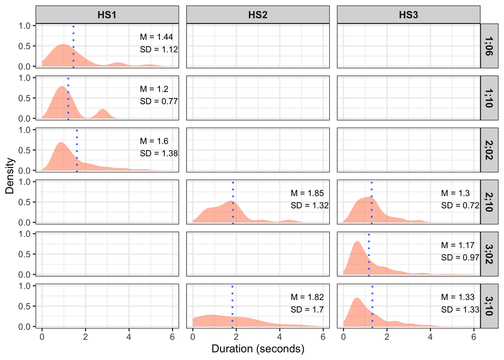

```r
ggsave("figures/FigureS2.png", fig_s2, width = 7, height = 5, dpi = 450)

fig_s3 <- child_density(filter(timed, language == "Homesign"), "coral")
fig_s3
```

```r
ggsave("figures/FigureS3.png", fig_s3, width = 7, height = 5, dpi = 450)
```